# Coursera Data Science Capstone Milestone Report

clpong

Saturday June 5, 2016

## Introduction

This milestone report is based on exploratory data analysis of the SwifKey data provided in the context of the Coursera Data Science Capstone. The data consist of 3 text files containing text from three different sources (blogs, news & twitter). Some of the code is hidden to preserve space, but can be accessed by looking at the Raw .Rmd, which can be found in my GitHub repository https://github.com/clpong/m10

## Data Summary

The data is acquired from https://d396qusza40orc.cloudfront.net/dsscapstone/dataset/Coursera-SwiftKey.zip.

**Packages, Libraries, Seed**

```r
setwd("c:/m10/")
library(dplyr)
library(doParallel)
library(stringi)
library(tm)
library(slam)
library(ggplot2)
library(wordcloud)
```

```r
# Setup parallel clusters to accelarate execution time
jobcluster <- makeCluster(detectCores())
invisible(clusterEvalQ(jobcluster, library(tm)))
invisible(clusterEvalQ(jobcluster, library(slam)))
invisible(clusterEvalQ(jobcluster, library(stringi)))
invisible(clusterEvalQ(jobcluster, library(wordcloud)))
```

**Downloading Raw Data**

```r
# Check for zip file and download if necessary
if (!file.exists("Coursera-SwiftKey.zip")) {
    download.file("https://d396qusza40orc.cloudfront.net/dsscapstone/dataset/Coursera-SwiftKey.zip",
        destfile = "Coursera-SwiftKey.zip")
}
# Check for data file and unzip if necessary
if (!file.exists("final/en_US/en_US.blogs.txt")) {
    unzip("Coursera-SwiftKey.zip", exdir = ".")
}
```

## Analysing Data

Basis data analysis done for line of records, character and word count, word per line and this iwll be displayed in the below histogram to identified distribution of the 3 sets of data.

**Loading 3 set of Data**

```r
conn <- file("final/en_US/en_US.blogs.txt", open = "rb")
blogs_dt <- readLines(conn, encoding = "UTF-8")
close(conn)

# Read news data in binary mode
conn <- file("final/en_US/en_US.news.txt", open = "rb")
news_dt <- readLines(conn, encoding = "UTF-8")
close(conn)

# Read twitter data in binary mode
conn <- file("final/en_US/en_US.twitter.txt", open = "rb")
twits_dt <- readLines(conn, encoding = "UTF-8")
```

**Mean Calculation for 3 sets of Data**

```r
# Compute words per line info on each line for each data type
rawWPL<-lapply(list(blogs_dt,news_dt,twits_dt),function(x) stri_count_words(x))

# Compute statistics and summary info for each data type
rawstats<-data.frame(
            File=c("blogs","news","twitter"),
            t(rbind(sapply(list(blogs_dt,news_dt,twits_dt),stri_stats_general),
                    TotalWords=sapply(list(blogs_dt,news_dt,twits_dt),stri_stats_latex)[4,])),
            # Compute words per line summary
            WPL=rbind(summary(rawWPL[[1]]),summary(rawWPL[[2]]),summary(rawWPL[[3]]))
            )
print(rawstats)
```

```
##      File   Lines LinesNEmpty     Chars CharsNWhite TotalWords WPL.Min. WPL.1st.Qu. WPL.Median WPL.Mean
## 1   blogs  899288      899288 206824382   170389539   37570839        0           9         28    41.75
## 2    news 1010242     1010242 203223154   169860866   34494539        1          19         32    34.41
## 3 twitter 2360148     2360148 162096031   134082634   30451128        1           7         12    12.75
##   WPL.3rd.Qu. WPL.Max.
## 1          60     6726
## 2          46     1796
## 3          18       47
```

From the statistics, we can see that, mean darta for Blogs, News and Twitter are respectively 41.7. 34.4 and 12.7 repectively.

**Plots Histogram for 3 sets of Data**

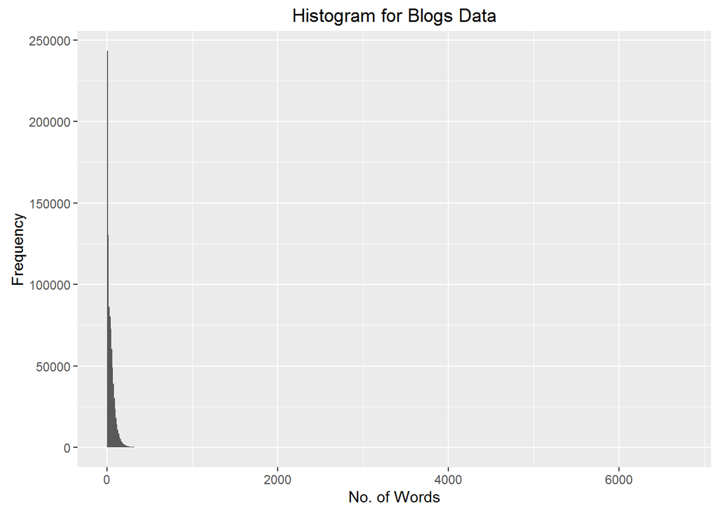

```r
qplot(rawWPL[[1]],geom="histogram",main="Histogram for Blogs Data",
      xlab="No. of Words",ylab="Frequency",binwidth=10)
```

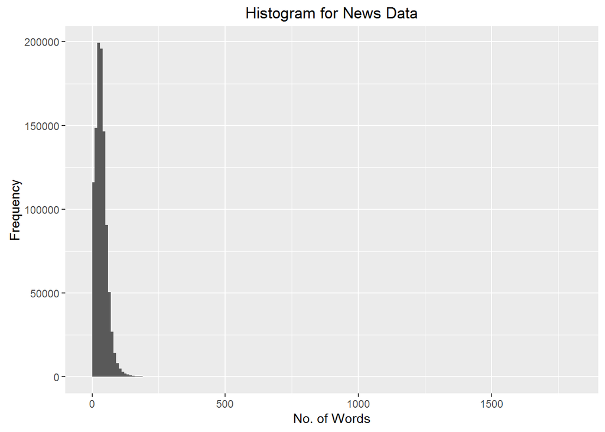

```r
qplot(rawWPL[[2]],geom="histogram",main="Histogram for News Data",
      xlab="No. of Words",ylab="Frequency",binwidth=10)
```

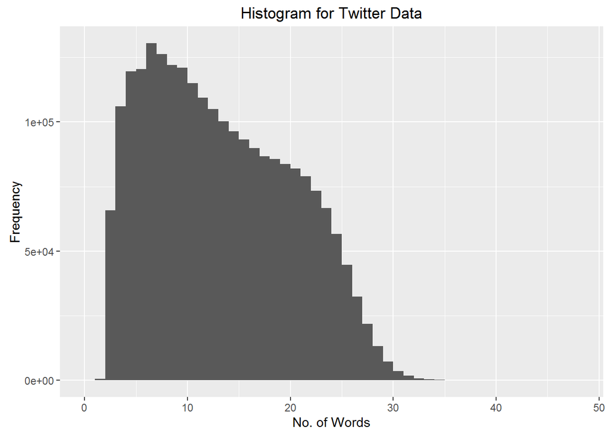

```r
qplot(rawWPL[[3]],geom="histogram",main="Histogram for Twitter Data",
      xlab="No. of Words",ylab="Frequency",binwidth=1)
```

```r
rm(rawWPL);rm(rawstats)
```

From the histograms plotted, we also notice that all data types are right-skewed.

## Sampling Data

We set sample data size = 10000 lines of data before data cleaning for exploratory analysis.

```r
samplesize <- 10000  # Assign sample size
set.seed(1000)  # Ensure reproducibility

# Create raw data and sample vectors
data <- list(blogs_dt, news_dt, twits_dt)
sample <- list()

# Iterate each raw data to create 'cleaned'' sample for each
for (i in 1:length(data)) {
    # Create sample dataset
    Filter <- sample(1:length(data[[i]]), samplesize, replace = FALSE)
    sample[[i]] <- data[[i]][Filter]
    # Remove unconvention/funny characters
    for (j in 1:length(sample[[i]])) {
        row1 <- sample[[i]][j]
        row2 <- iconv(row1, "latin1", "ASCII", sub = "")
        sample[[i]][j] <- row2
    }
}

rm(blogs_dt)
rm(news_dt)
rm(twits_dt)
```

## Creating corpus & Cleaning data

```r
# Create corpus and document term matrix vectors
corpus <- list()
dtMatrix <- list()

# Iterate each sample data to create corpus and DTM for each
for (i in 1:length(sample)) {
    # Create corpus dataset
    corpus[[i]] <- Corpus(VectorSource(sample[[i]]))
    # Cleaning/stemming the data
    corpus[[i]] <- tm_map(corpus[[i]], tolower)
    corpus[[i]] <- tm_map(corpus[[i]], removeNumbers)
    corpus[[i]] <- tm_map(corpus[[i]], removeWords, stopwords("english"))
    corpus[[i]] <- tm_map(corpus[[i]], removePunctuation)
    corpus[[i]] <- tm_map(corpus[[i]], stemDocument)
    corpus[[i]] <- tm_map(corpus[[i]], stripWhitespace)
    corpus[[i]] <- tm_map(corpus[[i]], PlainTextDocument)
    # calculate document term frequency for corpus
    dtMatrix[[i]] <- DocumentTermMatrix(corpus[[i]], control = list(wordLengths = c(0,
        Inf)))
}

rm(data)
rm(sample)
```

## Plotting WordCloud data

[figure not shown]

[figure not shown]

[figure not shown]

```r
set.seed(1000)  # Ensure reproducibility
par(mfrow = c(1, 1))  # Establish Plotting Panel
headings = c("Blogs Word Cloud Data", "News Word Cloud Data", "Twitter Word Cloud Data")

# Iterate each corpus/DTM and plot word cloud for each
for (i in 1:length(corpus)) {
    wordcloud(words = colnames(dtMatrix[[i]]), freq = col_sums(dtMatrix[[i]]),
        scale = c(3, 1), max.words = 100, random.order = FALSE, rot.per = 0.35,
        use.r.layout = FALSE, colors = brewer.pal(8, "Dark2"))
    title(headings[i])
}
```